```python
import pandas as pd;
import numpy as np
import seaborn as sns
import matplotlib.pyplot as plt
from sklearn.model_selection import train_test_split
import xgboost as xgb
%matplotlib inline
from sklearn.preprocessing import StandardScaler
from sklearn.preprocessing import MinMaxScaler
import time
from sklearn import metrics;
from math import sqrt
from sklearn.model_selection import cross_validate
import warnings
warnings.simplefilter("ignore")
from scipy.stats import uniform, randint
from sklearn.experimental import enable_halving_search_cv
from sklearn.model_selection import HalvingGridSearchCV
from sklearn.model_selection import cross_val_score, GridSearchCV, KFold, RandomizedSearchCV, train_test_split,HalvingGridSearchCV
xgb.set_config(verbosity=0)

from sklearn.preprocessing import LabelEncoder
from sklearn.linear_model import LogisticRegression
from sklearn.tree import DecisionTreeClassifier
from sklearn.ensemble import BaggingClassifier
from sklearn.ensemble import RandomForestClassifier
from sklearn.ensemble import GradientBoostingClassifier
from xgboost import XGBClassifier
from catboost import CatBoostClassifier
from lightgbm import LGBMClassifier
from sklearn.svm import SVC
from sklearn.neighbors import KNeighborsClassifier
import pickle
import math
from IPython.display import display
from tqdm import tnrange, tqdm_notebook
import math as math
cv_value=3
import sklearn
```

```python
sklearn.metrics.SCORERS.keys()
```

```
dict_keys(['explained_variance', 'r2', 'max_error', 'neg_median_absolute_error', 'neg_mean_absolute_error', 'neg_mean_absolute_percentage_error', 'neg_mean_squared_error', 'neg_mean_squared_log_error', 'neg_root_mean_squared_error', 'neg_mean_poisson_deviance', 'neg_mean_gamma_deviance', 'accuracy',…
```

# 1. Data Understanding & Exploration:

A. Read ‘TelcomCustomer-Churn_1.csv’ as a DataFrame and assign it to a variable.

```python
df1 = pd.read_csv('TelcomCustomer-Churn_1.csv')
df1.head()
```

|  | customerID | gender | SeniorCitizen | Partner | Dependents | tenure | PhoneService | MultipleLines | InternetService | OnlineSecurity |
| --- | --- | --- | --- | --- | --- | --- | --- | --- | --- | --- |
| 0 | 7590-VHVEG | Female | 0 | Yes | No | 1 | No | No phone service | DSL | No |
| 1 | 5575-GNVDE | Male | 0 | No | No | 34 | Yes | No | DSL | Yes |
| 2 | 3668-QPYBK | Male | 0 | No | No | 2 | Yes | No | DSL | Yes |
| 3 | 7795-CFOCW | Male | 0 | No | No | 45 | No | No phone service | DSL | Yes |
| 4 | 9237-HQITU | Female | 0 | No | No | 2 | Yes | No | Fiber optic | No |

B. Read ‘TelcomCustomer-Churn_2.csv’ as a DataFrame and assign it to a variable.

```python
df2 = pd.read_csv('TelcomCustomer-Churn_2.csv')
df2.head()
```

|  | customerID | OnlineBackup | DeviceProtection | TechSupport | StreamingTV | StreamingMovies | Contract | PaperlessBilling | PaymentMethod | MonthlyCharges | TotalCharges | Churn |
| --- | --- | --- | --- | --- | --- | --- | --- | --- | --- | --- | --- | --- |
| 0 | 7590-VHVEG | Yes | No | No | No | No | Month-to-month | Yes | Electronic check | 29.85 | 29.85 | No |
| 1 | 5575-GNVDE | No | Yes | No | No | No | One year | No | Mailed check | 56.95 | 1889.5 | No |
| 2 | 3668-QPYBK | Yes | No | No | No | No | Month-to-month | Yes | Mailed check | 53.85 | 108.15 | Yes |
| 3 | 7795-CFOCW | No | Yes | Yes | No | No | One year | No | Bank transfer (automatic) | 42.30 | 1840.75 | No |
| 4 | 9237-HQITU | No | No | No | No | No | Month-to-month | Yes | Electronic check | 70.70 | 151.65 | Yes |

C. Merge both the DataFrames on key ‘customerID’ to form a single DataFrame

```python
churn_df = pd.merge(df1, df2, on='customerID')
churn_df.reset_index(drop=True, inplace=True)
churn_df.head()
```

|  | customerID | gender | SeniorCitizen | Partner | Dependents | tenure | PhoneService | MultipleLines | InternetService | OnlineSecurity | ... | DeviceProtection | TechSupport | StreamingTV | StreamingMovies | Contract | PaperlessBilling | PaymentMethod | MonthlyCharges | TotalCharges | Churn |
| --- | --- | --- | --- | --- | --- | --- | --- | --- | --- | --- | --- | --- | --- | --- | --- | --- | --- | --- | --- | --- | --- |
| 0 | 7590-VHVEG | Female | 0 | Yes | No | 1 | No | No phone service | DSL | No | ... | No | No | No | No | Month-to-month | Yes | Electronic check | 29.85 | 29.85 | No |
| 1 | 5575-GNVDE | Male | 0 | No | No | 34 | Yes | No | DSL | Yes | ... | Yes | No | No | No | One year | No | Mailed check | 56.95 | 1889.5 | No |
| 2 | 3668-QPYBK | Male | 0 | No | No | 2 | Yes | No | DSL | Yes | ... | No | No | No | No | Month-to-month | Yes | Mailed check | 53.85 | 108.15 | Yes |
| 3 | 7795-CFOCW | Male | 0 | No | No | 45 | No | No phone service | DSL | Yes | ... | Yes | Yes | No | No | One year | No | Bank transfer (automatic) | 42.30 | 1840.75 | No |
| 4 | 9237-HQITU | Female | 0 | No | No | 2 | Yes | No | Fiber optic | No | ... | No | No | No | No | Month-to-month | Yes | Electronic check | 70.70 | 151.65 | Yes |

5 rows × 21 columns

### Save the merge content to CSV file

```python
churn_df.to_csv('merged.csv', index=False)
```

D. Verify if all the columns are incorporated in the merged DataFrame by using simple comparison Operator in Python.

### Check all columns of df1 present in merge dataframe

```python
if set(df1.columns).issubset(churn_df.columns):
    print('columns of df1 is included in merge dataset')
else:
    print('columns of df1 is NOT included in merge dataset')
```

```
columns of df1 is included in merge dataset
```

### Check all columns of df2 present in merge dataframe

```python
if set(df2.columns).issubset(churn_df.columns):
    print('columns of df2 is included in merge dataset')
else:
    print('columns of df2 is NOT included in merge dataset')
```

```
columns of df2 is included in merge dataset
```

# 2. Data Cleaning & Analysis:

A. Impute missing/unexpected values in the DataFrame.

#### Check for missing value

```python
churn_df.isna().sum()
```

```
customerID          0
gender              0
SeniorCitizen       0
Partner             0
Dependents          0
tenure              0
PhoneService        0
MultipleLines       0
InternetService     0
OnlineSecurity      0
OnlineBackup        0
DeviceProtection    0
TechSupport         0
StreamingTV         0
StreamingMovies     0
Contract            0
PaperlessBilling    0
PaymentMethod       0
MonthlyCharges      0
TotalCharges        0
Churn               0
dtype: int64
```

### Checking the info. That will give information regarding null value and datatype

```python
churn_df.info()
```

```
<class 'pandas.core.frame.DataFrame'>
RangeIndex: 7043 entries, 0 to 7042
Data columns (total 21 columns):
 #   Column            Non-Null Count  Dtype
---  ------            --------------  -----
 0   customerID        7043 non-null   object
 1   gender            7043 non-null   object
 2   SeniorCitizen     7043 non-null   int64
 3   Partner           7043 non-null   object
 4   Dependents        7043 non-null   object
 5   tenure            7043 non-null   int64
 6   PhoneService      7043 non-null   object
 7   MultipleLines     7043 non-null   object
 8   InternetService   7043 non-null   object
 9   OnlineSecurity    7043 non-null   object
 10  OnlineBackup      7043 non-null   object
 11  DeviceProtection  7043 non-null   object
 12  TechSupport       7043 non-null   object
 13  StreamingTV       7043 non-null   object
 14  StreamingMovies   7043 non-null   object
 15  Contract          7043 non-null   object
 16  PaperlessBilling  7043 non-null   object
 17  PaymentMethod     7043 non-null   object
 18  MonthlyCharges    7043 non-null   float64
 19  TotalCharges      7043 non-null   object
 20  Churn             7043 non-null   object
dtypes: float64(1), int64(2), object(18)
memory usage: 1.1+ MB
```

### Observation : TotalCharges column values should be a numerical column , but dataframe showing object. There might be some null or string type in column. But it is not captured in isna().sum() functions.

### SeniorCitizen is written in the form of 0 and 1 . 1 Means yes and 0 means NO

### Customer id contains unique value. This should not be used in model prediction as it is always unique for each customer

### Check for Unexpected value in DF by using the unique() function

```python
print("Printing unique column of each column except customerID")
for column in churn_df.drop('customerID', axis=1).columns:
    print("{} ->  {} ".format(column,churn_df[column].unique()))
```

```
Printing unique column of each column except customerID
gender ->  ['Female' 'Male']
SeniorCitizen ->  [0 1]
Partner ->  ['Yes' 'No']
Dependents ->  ['No' 'Yes']
tenure ->  [ 1 34  2 45  8 22 10 28 62 13 16 58 49 25 69 52 71 21 12 30 47 72 17 27
  5 46 11 70 63 43 15 60 18 66  9  3 31 50 64 56  7 42 35 48 29 65 38 68
 32 55 37 36 41  6  4 33 67 23 57 61 14 20 53 40 59 24 44 19 54 51 26  0
 39]
PhoneService ->  ['No' 'Yes']
MultipleLines ->  ['No phone service' 'No' 'Yes']
InternetService ->  ['DSL' 'Fiber optic' 'No']
OnlineSecurity ->  ['No' 'Yes' 'No internet service']
OnlineBackup ->  ['Yes' 'No' 'No internet service']
DeviceProtection ->  ['No' 'Yes' 'No internet service']
TechSupport ->  ['No' 'Yes' 'No internet service']
StreamingTV ->  ['No' 'Yes' 'No internet service']
StreamingMovies ->  ['No' 'Yes' 'No internet service']
Contract ->  ['Month-to-month' 'One year' 'Two year']
PaperlessBilling ->  ['Yes' 'No']
PaymentMethod ->  ['Electronic check' 'Mailed check' 'Bank transfer (automatic)'
 'Credit card (automatic)']
MonthlyCharges ->  [29.85 56.95 53.85 ... 63.1  44.2  78.7 ]
TotalCharges ->  ['29.85' '1889.5' '108.15' ... '346.45' '306.6' '6844.5']
Churn ->  ['No' 'Yes']
```

### ------------------------------------------------

### Converting Spaces cell with nan value. So that we can either drop it or replace with median value

```python
churn_df['TotalCharges'] = np.where((churn_df['TotalCharges'].astype(str).str.fullmatch(r"\s*")),np.nan,churn_df['TotalCharges'])
```

### From the above command, we are replacing multiple spaces with NaN value. Through NaN value, we can either drop it and replace it with mean/median/Mode

### After converting it to NaN, checking the count of Null/Missing value

```python
churn_df.isna().sum()
```

```
customerID           0
gender               0
SeniorCitizen        0
Partner              0
Dependents           0
tenure               0
PhoneService         0
MultipleLines        0
InternetService      0
OnlineSecurity       0
OnlineBackup         0
DeviceProtection     0
TechSupport          0
StreamingTV          0
StreamingMovies      0
Contract             0
PaperlessBilling     0
PaymentMethod        0
MonthlyCharges       0
TotalCharges        11
Churn                0
dtype: int64
```

### Printing all the records which has missing value

```python
churn_df.loc[churn_df.TotalCharges.isnull()]
```

|  | customerID | gender | SeniorCitizen | Partner | Dependents | tenure | PhoneService | MultipleLines | InternetService | OnlineSecurity | ... | DeviceProtection | TechSupport | StreamingTV | StreamingMovies | Contract | PaperlessBilling | PaymentMethod | MonthlyCharges | TotalCharges | Churn |
| --- | --- | --- | --- | --- | --- | --- | --- | --- | --- | --- | --- | --- | --- | --- | --- | --- | --- | --- | --- | --- | --- |
| 488 | 4472-LVYGI | Female | 0 | Yes | Yes | 0 | No | No phone service | DSL | Yes | ... | Yes | Yes | Yes | No | Two year | Yes | Bank transfer (automatic) | 52.55 | NaN | No |
| 753 | 3115-CZMZD | Male | 0 | No | Yes | 0 | Yes | No | No | No internet service | ... | No internet service | No internet service | No internet service | No internet service | Two year | No | Mailed check | 20.25 | NaN | No |
| 936 | 5709-LVOEQ | Female | 0 | Yes | Yes | 0 | Yes | No | DSL | Yes | ... | Yes | No | Yes | Yes | Two year | No | Mailed check | 80.85 | NaN | No |
| 1082 | 4367-NUYAO | Male | 0 | Yes | Yes | 0 | Yes | Yes | No | No internet service | ... | No internet service | No internet service | No internet service | No internet service | Two year | No | Mailed check | 25.75 | NaN | No |
| 1340 | 1371-DWPAZ | Female | 0 | Yes | Yes | 0 | No | No phone service | DSL | Yes | ... | Yes | Yes | Yes | No | Two year | No | Credit card (automatic) | 56.05 | NaN | No |
| 3331 | 7644-OMVMY | Male | 0 | Yes | Yes | 0 | Yes | No | No | No internet service | ... | No internet service | No internet service | No internet service | No internet service | Two year | No | Mailed check | 19.85 | NaN | No |
| 3826 | 3213-VVOLG | Male | 0 | Yes | Yes | 0 | Yes | Yes | No | No internet service | ... | No internet service | No internet service | No internet service | No internet service | Two year | No | Mailed check | 25.35 | NaN | No |
| 4380 | 2520-SGTTA | Female | 0 | Yes | Yes | 0 | Yes | No | No | No internet service | ... | No internet service | No internet service | No internet service | No internet service | Two year | No | Mailed check | 20.00 | NaN | No |
| 5218 | 2923-ARZLG | Male | 0 | Yes | Yes | 0 | Yes | No | No | No internet service | ... | No internet service | No internet service | No internet service | No internet service | One year | Yes | Mailed check | 19.70 | NaN | No |
| 6670 | 4075-WKNIU | Female | 0 | Yes | Yes | 0 | Yes | Yes | DSL | No | ... | Yes | Yes | Yes | No | Two year | No | Mailed check | 73.35 | NaN | No |
| 6754 | 2775-SEFEE | Male | 0 | No | Yes | 0 | Yes | Yes | DSL | Yes | ... | No | Yes | No | No | Two year | Yes | Bank transfer (automatic) | 61.90 | NaN | No |

11 rows × 21 columns

### There are total 11 null value in TotalCharge columns.

### This value need to be impute with median value.

```python
churn_df['TotalCharges'] = churn_df['TotalCharges'].fillna(churn_df['TotalCharges'].median())
```

```python
churn_df.isnull().sum()
```

```
customerID          0
gender              0
SeniorCitizen       0
Partner             0
Dependents          0
tenure              0
PhoneService        0
MultipleLines       0
InternetService     0
OnlineSecurity      0
OnlineBackup        0
DeviceProtection    0
TechSupport         0
StreamingTV         0
StreamingMovies     0
Contract            0
PaperlessBilling    0
PaymentMethod       0
MonthlyCharges      0
TotalCharges        0
Churn               0
dtype: int64
```

### No more null value are present in the dataset. Missing value has been imputed with median value

B. Make sure all the variables with continuous values are of ‘Float’ type.

```python
churn_df.info()
```

```
<class 'pandas.core.frame.DataFrame'>
RangeIndex: 7043 entries, 0 to 7042
Data columns (total 21 columns):
 #   Column            Non-Null Count  Dtype
---  ------            --------------  -----
 0   customerID        7043 non-null   object
 1   gender            7043 non-null   object
 2   SeniorCitizen     7043 non-null   int64
 3   Partner           7043 non-null   object
 4   Dependents        7043 non-null   object
 5   tenure            7043 non-null   int64
 6   PhoneService      7043 non-null   object
 7   MultipleLines     7043 non-null   object
 8   InternetService   7043 non-null   object
 9   OnlineSecurity    7043 non-null   object
 10  OnlineBackup      7043 non-null   object
 11  DeviceProtection  7043 non-null   object
 12  TechSupport       7043 non-null   object
 13  StreamingTV       7043 non-null   object
 14  StreamingMovies   7043 non-null   object
 15  Contract          7043 non-null   object
 16  PaperlessBilling  7043 non-null   object
 17  PaymentMethod     7043 non-null   object
 18  MonthlyCharges    7043 non-null   float64
 19  TotalCharges      7043 non-null   object
 20  Churn             7043 non-null   object
dtypes: float64(1), int64(2), object(18)
memory usage: 1.1+ MB
```

```python
churn_df['MonthlyCharges'] = churn_df['MonthlyCharges'].astype('float')
churn_df['TotalCharges'] = churn_df['TotalCharges'].astype('float')
```

### Check the data type again to ensure that it has been converted into float

```python
churn_df.info()
```

```
<class 'pandas.core.frame.DataFrame'>
RangeIndex: 7043 entries, 0 to 7042
Data columns (total 21 columns):
 #   Column            Non-Null Count  Dtype
---  ------            --------------  -----
 0   customerID        7043 non-null   object
 1   gender            7043 non-null   object
 2   SeniorCitizen     7043 non-null   int64
 3   Partner           7043 non-null   object
 4   Dependents        7043 non-null   object
 5   tenure            7043 non-null   int64
 6   PhoneService      7043 non-null   object
 7   MultipleLines     7043 non-null   object
 8   InternetService   7043 non-null   object
 9   OnlineSecurity    7043 non-null   object
 10  OnlineBackup      7043 non-null   object
 11  DeviceProtection  7043 non-null   object
 12  TechSupport       7043 non-null   object
 13  StreamingTV       7043 non-null   object
 14  StreamingMovies   7043 non-null   object
 15  Contract          7043 non-null   object
 16  PaperlessBilling  7043 non-null   object
 17  PaymentMethod     7043 non-null   object
 18  MonthlyCharges    7043 non-null   float64
 19  TotalCharges      7043 non-null   float64
 20  Churn             7043 non-null   object
dtypes: float64(2), int64(2), object(17)
memory usage: 1.1+ MB
```

### Remove customerID , as it is not important feature

```python
churn_df.drop('customerID', axis=1, inplace=True)
```

C. Create a function that will accept a DataFrame as input and return pie-charts for all the appropriate Categorical features. Clearly show percentage distribution in the pie-chart.

```python
import math as math
def make_autopct(values):
    def my_autopct(pct):
        total = sum(values)
        val = int(round(pct*total/100.0))
        return '{p:.2f}%  ({v:d})'.format(p=pct,v=val)
    return my_autopct
def plotpieChart(df):
    cat_df = df.select_dtypes(include=["object"])
    for column in cat_df.columns:
        fig = plt.figure(figsize=(10,3))
        ax1 = fig.add_subplot(121)
        data = cat_df.groupby(column).size()
        data.plot(kind='pie',textprops={'fontsize': 10},
                                           autopct=lambda p: '{:.2f}%({:.0f})'.format(p,(p/100)*data.sum()), shadow=True)
        ax1.set_xlabel(column, size=22)
        ax1.set_ylabel('')
        plt.tight_layout()
        plt.show()
```

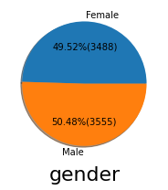

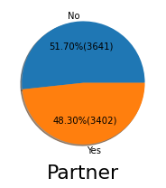

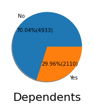

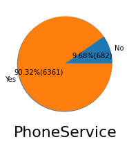

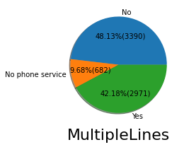

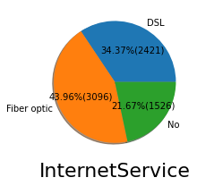

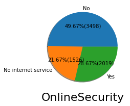

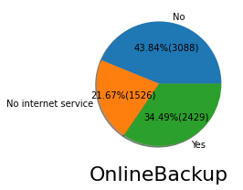

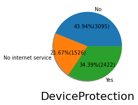

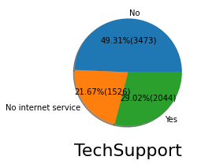

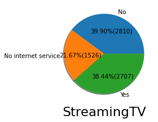

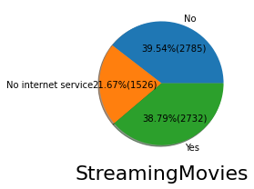

[4 more figures not shown]

```python
plotpieChart(churn_df)
```

### There are 42.18% customer who uses multipleLines service and 48% dont. 10% of the customer have NO Phone Service.

### 44 % of customer use Fiber optic and 34% DSL . There are 22% people who dont use Internet service.

### 29% of customer uses Online security and 50% dont. 22% have no Internet service at all.

### 34% of customer uses online backup and 44% dont. 22% have no Internet service at all.

### 34% of customer uses Device Protection and 44% dont. 22% have no Internet service at all.

### 29% of customer uses TechSupport and 49% dont. 22% have no Internet service at all.

### 38% of customer uses StreamingTv and 40% dont. 22% have no Internet service at all.

### 39% of customer uses StreamingMovie and 40% dont. 22% have no Internet service at all.

### 21% of customer have one year contract, 24% have two year and 55% have month to month

### 59% of customer have opted for PaperlessBilling and 41% has no opted.

### 34% use electronic heck for paymentMethod, 23% use mailed check, 22% use credit card for payment and 22% uses bank transfer automatically.

### 73% of customer dont churn and 27% have churn.

### Check how churn depend on tenure

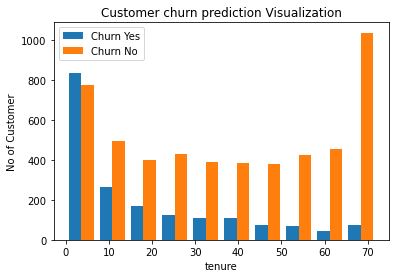

```python
tenure_churn_no = churn_df[churn_df.Churn =='No'].tenure
tenure_churn_yes = churn_df[churn_df.Churn =='Yes'].tenure
plt.hist([tenure_churn_yes, tenure_churn_no], label=['Churn Yes', 'Churn No']);
plt.xlabel("tenure")
plt.ylabel("No of Customer")
plt.title('Customer churn prediction Visualization')
plt.legend()
```

### The customers whose tenure less than 5 month, are leaving

#### churn rate is going down when the tenure is increaing.

### Customer having 70 months of tenure are very less chance of leaving. Churn is very low.

### Check how churn depend on Monthly Charges

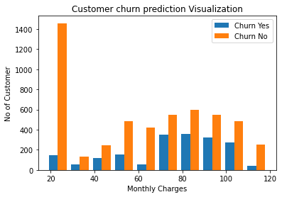

```python
monthlyCharges_churn_no = churn_df[churn_df.Churn =='No'].MonthlyCharges
monthlyCharges_churn_yes = churn_df[churn_df.Churn =='Yes'].MonthlyCharges
plt.hist([monthlyCharges_churn_yes, monthlyCharges_churn_no], label=['Churn Yes', 'Churn No']);
plt.xlabel("Monthly Charges")
plt.ylabel("No of Customer")
plt.title('Customer churn prediction Visualization')
plt.legend()
```

### Seems like customer whose monthly charges are around 70 to 100 are more chance of leaving

### Majority of people whose monthly charges are around 20-30 are not leaving

### Check how churn depend on Total Charges

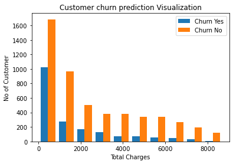

```python
totalCharges_churn_no = churn_df[churn_df.Churn =='No'].TotalCharges
totalCharges_churn_yes = churn_df[churn_df.Churn =='Yes'].TotalCharges
plt.hist([totalCharges_churn_yes, totalCharges_churn_no], label=['Churn Yes', 'Churn No']);
plt.xlabel("Total Charges")
plt.ylabel("No of Customer")
plt.title('Customer churn prediction Visualization')
plt.legend()
```

### Around 1000 customer whose total charges are less than 1000 are leaving.

### There is very less number of churn when the total charges are around 8000.

E. Encode all the appropriate Categorical features with the best suitable approach.

### Replacing No internet service with No. As both are representing the same meaning

```python
replace_cols = [ 'OnlineSecurity', 'OnlineBackup', 'DeviceProtection','TechSupport','StreamingTV', 'StreamingMovies']
for i in replace_cols :
    churn_df[i]  = churn_df[i].replace({'No internet service' : 'No'})
```

### Convert catagorical featuren to number using label encoder. Since machine only understand numbers

#### Here we use labelEncoding for converting all categorical feature to number. IN part B, both one hot encoding and label encoding is used,

```python
mapping = {}
labelEncoder = LabelEncoder();
def encode_catagorical_column(df):

    for column in df.select_dtypes(include=['object']):
        labelEncoder.fit(df[column])
        le_name_mapping = dict(zip(labelEncoder.classes_, labelEncoder.transform(labelEncoder.classes_)))
        mapping = dict(zip(column, le_name_mapping))
        df[column]=labelEncoder.transform(df[column])
```

```python
encode_catagorical_column(churn_df)
```

### Find the correlation between the features. If onehotencoding was used earlier, we cannot find the corelation as many features are converted to multiple column and some values are removed

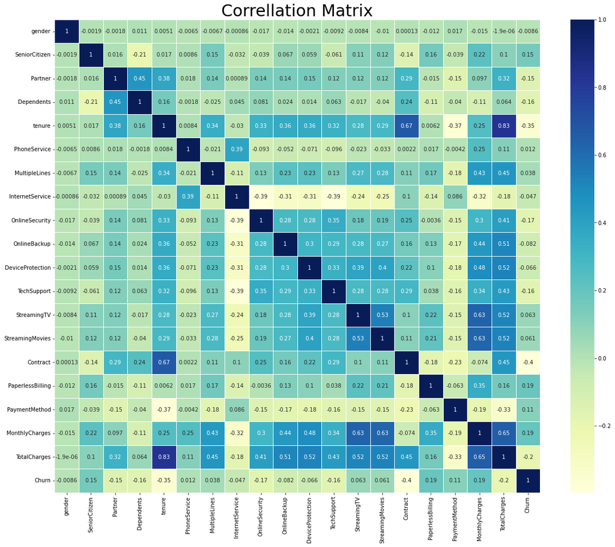

```python
plt.subplots(figsize=(20, 16))
plt.title('Correllation Matrix', size=30)
sns.heatmap(churn_df.corr(),annot=True,linewidths=0.5, cmap='YlGnBu');
```

### There is corelation between churn and monthlycharges, paperlessBilling, paymenmethod

### Total charges is highly dependent on the tenure and monthlycharges

### Contract and tenure is highly correlateed

### Monthly charges and streaming movie is highly correlated

F. Split the data into 80% train and 20% test.

```python
X = churn_df.drop('Churn',axis=1)
y = churn_df[['Churn']]
X_train, X_test, y_train, y_test = train_test_split(X, y, test_size=0.20, random_state=1)
```

G. Normalize/Standardize the data with the best suitable approach.

```python
X_train.describe().T
```

|  | count | mean | std | min | 25% | 50% | 75% | max |
| --- | --- | --- | --- | --- | --- | --- | --- | --- |
| gender | 5634.0 | 0.503727 | 0.500030 | 0.00 | 0.000 | 1.000 | 1.00 | 1.00 |
| SeniorCitizen | 5634.0 | 0.161874 | 0.368368 | 0.00 | 0.000 | 0.000 | 0.00 | 1.00 |
| Partner | 5634.0 | 0.479588 | 0.499628 | 0.00 | 0.000 | 0.000 | 1.00 | 1.00 |
| Dependents | 5634.0 | 0.295705 | 0.456399 | 0.00 | 0.000 | 0.000 | 1.00 | 1.00 |
| tenure | 5634.0 | 32.277955 | 24.555211 | 0.00 | 9.000 | 29.000 | 55.00 | 72.00 |
| PhoneService | 5634.0 | 0.902911 | 0.296105 | 0.00 | 1.000 | 1.000 | 1.00 | 1.00 |
| MultipleLines | 5634.0 | 0.944444 | 0.948675 | 0.00 | 0.000 | 1.000 | 2.00 | 2.00 |
| InternetService | 5634.0 | 0.873447 | 0.737614 | 0.00 | 0.000 | 1.000 | 1.00 | 2.00 |
| OnlineSecurity | 5634.0 | 0.286120 | 0.451986 | 0.00 | 0.000 | 0.000 | 1.00 | 1.00 |
| OnlineBackup | 5634.0 | 0.339901 | 0.473717 | 0.00 | 0.000 | 0.000 | 1.00 | 1.00 |
| DeviceProtection | 5634.0 | 0.344338 | 0.475194 | 0.00 | 0.000 | 0.000 | 1.00 | 1.00 |
| TechSupport | 5634.0 | 0.289670 | 0.453649 | 0.00 | 0.000 | 0.000 | 1.00 | 1.00 |
| StreamingTV | 5634.0 | 0.384629 | 0.486551 | 0.00 | 0.000 | 0.000 | 1.00 | 1.00 |
| StreamingMovies | 5634.0 | 0.390486 | 0.487903 | 0.00 | 0.000 | 0.000 | 1.00 | 1.00 |
| Contract | 5634.0 | 0.687611 | 0.831882 | 0.00 | 0.000 | 0.000 | 1.00 | 2.00 |
| PaperlessBilling | 5634.0 | 0.589457 | 0.491976 | 0.00 | 0.000 | 1.000 | 1.00 | 1.00 |
| PaymentMethod | 5634.0 | 1.582890 | 1.067389 | 0.00 | 1.000 | 2.000 | 2.00 | 3.00 |
| MonthlyCharges | 5634.0 | 64.779127 | 30.104993 | 18.25 | 35.400 | 70.375 | 89.85 | 118.65 |
| TotalCharges | 5634.0 | 2279.408298 | 2265.028889 | 18.80 | 392.775 | 1397.100 | 3787.50 | 8684.80 |

TotalCharges , Motnhly Charges and tenure has very large number and other columns are having 2-3 as max value. We need to normalize/Standardize the value

### Tenure, MonthlyCharges and TotalCharges are having extreme value compared to other columns. Other features are having 0,1,2 values only. So Normalize/Standardize should be taken.

```python
columns = X_train.columns
numerical_columns = ['tenure', 'MonthlyCharges', 'TotalCharges']
```

### Normalize the dataSet

```python
X_train_norm = X_train.copy()
X_test_norm = X_test.copy()
norm = MinMaxScaler().fit(X_train[numerical_columns])
norm.transform(X_train_norm[numerical_columns])
X_train_norm[numerical_columns] = norm.transform(X_train_norm[numerical_columns])
X_test_norm[numerical_columns] = norm.transform(X_test[numerical_columns])
```

### Standardize the dataset

```python
X_train_std = X_train.copy()
X_test_std = X_test.copy()
std = StandardScaler().fit(X_train_std[numerical_columns])
X_train_std[numerical_columns] = std.transform(X_train_std[numerical_columns])
X_test_std[numerical_columns] = std.transform(X_test_std[numerical_columns])
```

1. Model building and Improvement:

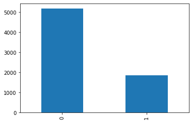

```python
churn_df.Churn.value_counts().plot(kind ='bar')
```

### There is imbalance in the dataset. So performance would be judge based on AUC score instead of accuracy.

A. Train a model using XGBoost. Also print best performing parameters along with train and test performance.

```python
def printConfusionMetric(y_test, y_pre, labels):
    '''
    This method help user to print the confusion metrics .
    param 1: Accept the y actual output
    param 2: Predicted outcome from the model
    Return : None
    '''
    cm = metrics.confusion_matrix(y_test, y_pre, labels=labels)
    df_cm = pd.DataFrame(cm, index = [i for i in ['Churn Yes', 'Churn  No']],
                  columns = ["Predict "+ str(i) for i in ['Churn Yes', 'Churn No']])
    plt.figure(figsize = (7,5));
    plt.xlabel('Predicted Label')
    plt.ylabel('Actual Label')
    sns.heatmap(df_cm, annot=True, fmt='g');
```

```python
def fit_n_print(model, X_train_p, X_test_p, y_train, y_test):  # take the model, train data and test data as input
    '''
    This method accept the model and train, test data.
    This method do  the accuracy, AUC, Cross Validation and return the response. This method perform 3 Cross validation.
    Param 1: It accept the model
    Param 2: X_train is the training data
    Param 3: X_test_p is the testing data
    Param 4: y_train_p is the y variable of training data
    Param 5: y_test is the y variable of training data
    '''
    start = time.time()  # note the start time
    if isinstance(model, XGBClassifier) :
        model.fit(X_train_p, y_train, early_stopping_rounds=5, eval_set=[(X_test_p, y_test)], eval_metric='auc')   # fit the model using the train data
    else:
        model.fit(X_train_p, y_train);

    pred = model.predict(X_test_p)     # model predictions on the test data
    accuracy_train = model.score(X_train_p, y_train)# calculate the accuracy on the train data
    #print(y_test)
    accuracy_test = model.score(X_test_p, y_test)  # calculate the accuracy on the test data


    precision = metrics.precision_score(y_test, pred)
    recall = metrics.recall_score(y_test, pred)
    auc = metrics.roc_auc_score(y_test, pred)
    scorer = {'accuracy' : metrics.make_scorer(metrics.accuracy_score),
              'precision' : metrics.make_scorer(metrics.precision_score),
              'recall' : metrics.make_scorer(metrics.recall_score),
              'f1' : metrics.make_scorer(metrics.f1_score),
               }    # make scorers to be used in cross validation

    cv = cross_validate(model, X_train_p, y_train, cv=cv_value, scoring = scorer, n_jobs=-1)   # perform cross validation accross 4 metrics

    accuracy_cv = cv['test_accuracy'].mean()
    precision_cv =  cv['test_precision'].mean()
    recall_cv =  cv['test_recall'].mean()
    f1_cv =  cv['test_f1'].mean()
    labels = [1,0]
    printConfusionMetric(y_test, pred, labels)
    end = time.time()  #note the end time


    duration = end - start  # calculate the total duration


    return accuracy_train, accuracy_test,auc, precision, recall, accuracy_cv, precision_cv, recall_cv, f1_cv, duration,pred
```

```python
def printResult(result):
    '''
    This method will print score in the form of table. It accept the dictionary object which has all the scores
    Param: result
    return Dataframe coming out from result
    '''
    result1 = pd.DataFrame(np.array(list(result.values()))[:,:-1],    # make a dataframe out of the metrics from result dictionary
                       columns= ['Training accuracy','Tesing accuracy ', 'auc','precision', 'recall', 'accuracy_cv', 'precision_cv', 'recall_cv', 'f1_cv', 'Elapsed'],
                      index= result.keys())   # use the model names as index

    result1.index.name = 'Model'   # name the index of the result1 dataframe as 'Model'

    return result1
```

```python
def compareConfusionMatrix(modelName, y_test, y_pre_org, y_pre_norm, y_pre_std, labels):
    fig,axs = plt.subplots(nrows=1, ncols=3, figsize=(15,4))
    cm = metrics.confusion_matrix(y_test, y_pre_org, labels=labels)
    df_cm = pd.DataFrame(cm, index = [i for i in ['Churn Yes', 'Churn No']],
                  columns = ["Predict "+ str(i) for i in ['Churn Yes', 'Churn No']])
    axs[0].set_title('CM for '+ modelName + ' orgnl Dataset')
    axs[0].set_xlabel('Predicted')
    axs[0].set_ylabel('Original')
    sns.heatmap(df_cm, annot=True, fmt='g',ax=axs[0]);


    cm = metrics.confusion_matrix(y_test, y_pre_norm, labels=labels)
    df_cm = pd.DataFrame(cm, index = [i for i in ['Churn Yes', 'Churn No']],
                  columns = ["Predict "+ str(i) for i in ['Churn Yes', 'Churn No']])
    #plt.figure(figsize = (7,5))
    axs[1].set_xlabel('Predicted')
    axs[1].set_ylabel('Original')
    axs[1].set_title('CM for '+ modelName + ' Normalize Dataset')
    sns.heatmap(df_cm, annot=True, fmt='g',ax=axs[1])



    cm = metrics.confusion_matrix(y_test, y_pre_std, labels=labels)
    df_cm = pd.DataFrame(cm, index = [i for i in ['Churn Yes', 'Churn No']],
                  columns = ["Predict "+ str(i) for i in ['Churn Yes', 'Churn No']])
    #plt.figure(figsize = (7,5));
    axs[2].set_xlabel('Predicted')
    axs[2].set_ylabel('Original')
    sns.heatmap(df_cm, annot=True, fmt='g',ax=axs[2]);
    axs[2].set_title('CM for '+ modelName + ' Standardize Dataset');
```

### Checking the accuracy of base model with Normalize dataset , Standarize dataset and orginal Dataset and compare the result.

```python
result={}
xgbClf = xgb.XGBClassifier(random_state=42)
result['BaseModel-with-original-dataset'] = fit_n_print(xgbClf, X_train, X_test, y_train, y_test)
result['BaseModel-Normalize-DataSet'] = fit_n_print(xgbClf, X_train_norm, X_test_norm, y_train, y_test)
result['BaseModel-Standardize-DataSet'] = fit_n_print(xgbClf, X_train_std, X_test_std, y_train, y_test)
```

```python
printResult(result)
```

| Model | Training accuracy | Tesing accuracy | auc | precision | recall | accuracy_cv | precision_cv | recall_cv | f1_cv | Elapsed |
| --- | --- | --- | --- | --- | --- | --- | --- | --- | --- | --- |
| BaseModel-with-original-dataset | 0.830138 | 0.814053 | 0.73653 | 0.634375 | 0.583333 | 0.772453 | 0.589843 | 0.51808 | 0.551527 | 2.139867 |
| BaseModel-Normalize-DataSet | 0.830138 | 0.814053 | 0.73653 | 0.634375 | 0.583333 | 0.772808 | 0.590724 | 0.51808 | 0.551907 | 1.803187 |
| BaseModel-Standardize-DataSet | 0.830138 | 0.814053 | 0.73653 | 0.634375 | 0.583333 | 0.772808 | 0.590827 | 0.517423 | 0.551574 | 1.668421 |

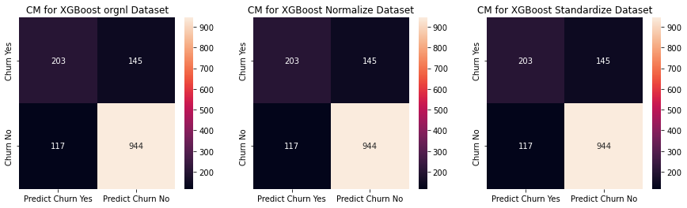

```python
compareConfusionMatrix('XGBoost', y_test, result['BaseModel-with-original-dataset'][10], result['BaseModel-Normalize-DataSet'][10], result['BaseModel-Standardize-DataSet'][10], labels=[1,0])
```

### Accuracy and AUC score are very same in three scaling dataset. We can use any dataset for further processing. But still we need to do hypertuning and see which dataset is giving best performance .

```python
def report_best_scores(results, n_top=3):
    ''' This method print the top rank parameter and model.
    If more than 1  parameter is giving same accuracy, then it will print all the parameters. By default it will print top 3 model
    param 1: results contains resultset of cross validation
    '''
    for i in range(1, n_top + 1):
        candidates = np.flatnonzero(results['rank_test_score'] == i)
        for candidate in candidates:
            print("Model with rank: {0}".format(i))
            print("Mean validation score: {0:.3f} (std: {1:.3f})".format(
                  results['mean_test_score'][candidate],
                  results['std_test_score'][candidate]))
            print("Parameters: {0}".format(results['params'][candidate]))
            print("")
```

```python
def report_randomiseSearchCV(model, model_params, X_train, y_train,X_test,y_test):
    '''
    This method is used to hyper tune the parameters. This method the train dataset and do the CV.
    3 cross validation is used in this casestudy. n_jobs=-1 represent it use all the cores available. It enhace the processing.
    Param 1: Accept the mode;
    Param 2: Accept the model parameter
    Param 3: Accept the X train dataset
    Param 4: Accept the y train dataset
    '''
    fit_params={"early_stopping_rounds":20,
            "eval_metric" : 'auc',
            "eval_set" : [(X_test,y_test)]
               }
    search = RandomizedSearchCV(model, param_distributions=model_params, random_state=42, n_iter=200, cv=cv_value, verbose=1, n_jobs=-1,refit=True, return_train_score=True, scoring='roc_auc')
    if (isinstance(model, LGBMClassifier) or isinstance(model, XGBClassifier)):
        search.fit(X_train, y_train, **fit_params)
    else:
        search.fit(X_train, y_train)

    report_best_scores(search.cv_results_, 1)
    print(search.best_estimator_)
    return search.best_estimator_
```

### Hypertune paramete of XGBoost

```python
params = {
    "colsample_bytree": uniform(0.7, 0.3),
    "gamma": uniform(0.2, 0.5),
    "learning_rate": uniform(0.01, 0.2), # default 0.1
    "max_depth": randint(2, 5), # default 3
    "n_estimators": randint(100, 200), # default 100
    "subsample": uniform(0.6, 0.4)
}
```

### Performing Hypertuning of XGBClassifier model with original Dataset

```python
model = report_randomiseSearchCV(xgb.XGBClassifier(random_state=42), params, X_train, y_train, X_test, y_test)
```

```
Fitting 3 folds for each of 200 candidates, totalling 600 fits
Model with rank: 1
Mean validation score: 0.845 (std: 0.009)
Parameters: {'colsample_bytree': 0.712218640695691, 'gamma': 0.6277302920055037, 'learning_rate': 0.15073157187600475, 'max_depth': 3, 'n_estimators': 189, 'subsample': 0.7966463500467329}

XGBClassifier(base_score=0.5, booster='gbtree', colsample_bylevel=1,
              colsample_bynode=1, colsample_bytree=0.712218640695691,
              enable_categorical=False, gamma=0.6277302920055037, gpu_id=-1,
              importance_type=None, interaction_constraints='',
              learning_rate=0.15073157187600475, max_delta_step=0, max_depth=3,
              min_child_weight=1, missing=nan, monotone_constraints='()',
              n_estimators=189, n_jobs=8, num_parallel_tree=1, predictor='auto',
              random_state=42, reg_alpha=0, reg_lambda=1, scale_pos_weight=1,
              subsample=0.7966463500467329, tree_method='exact',
              validate_parameters=1, verbosity=None)
```

### Taking the best Estimator and tune our model

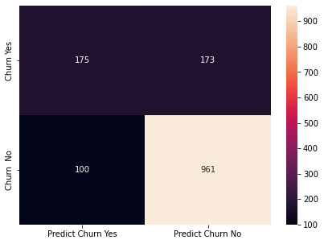

```python
result['TuningModel-with-original-dataset'] = fit_n_print(model, X_train, X_test, y_train, y_test)
```

### Performing Hypertuning of XGBClassifier model with Normalize Dataset

```python
model = report_randomiseSearchCV(xgb.XGBClassifier(random_state=42), params,  X_train_norm, y_train, X_test_norm, y_test)
```

```
Fitting 3 folds for each of 200 candidates, totalling 600 fits
Model with rank: 1
Mean validation score: 0.845 (std: 0.009)
Parameters: {'colsample_bytree': 0.7276871758686237, 'gamma': 0.4405726970281466, 'learning_rate': 0.14755694341921663, 'max_depth': 3, 'n_estimators': 162, 'subsample': 0.750914386096829}

XGBClassifier(base_score=0.5, booster='gbtree', colsample_bylevel=1,
              colsample_bynode=1, colsample_bytree=0.7276871758686237,
              enable_categorical=False, gamma=0.4405726970281466, gpu_id=-1,
              importance_type=None, interaction_constraints='',
              learning_rate=0.14755694341921663, max_delta_step=0, max_depth=3,
              min_child_weight=1, missing=nan, monotone_constraints='()',
              n_estimators=162, n_jobs=8, num_parallel_tree=1, predictor='auto',
              random_state=42, reg_alpha=0, reg_lambda=1, scale_pos_weight=1,
              subsample=0.750914386096829, tree_method='exact',
              validate_parameters=1, verbosity=None)
```

### Taking the best Estimator and tune our normalize dataset model

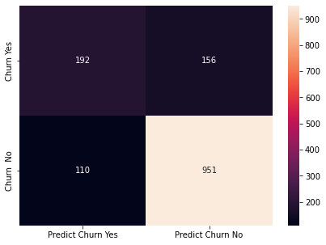

```python
result['TunedModel-Normalize-DataSet'] = fit_n_print(model, X_train_norm, X_test_norm, y_train, y_test)
```

### Performing Hypertuning of XGBClassifier model with Standarize Dataset

```python
model = report_randomiseSearchCV(xgb.XGBClassifier(random_state=42),params, X_train_std, y_train, X_test_std, y_test)
```

```
Fitting 3 folds for each of 200 candidates, totalling 600 fits
Model with rank: 1
Mean validation score: 0.846 (std: 0.009)
Parameters: {'colsample_bytree': 0.7276871758686237, 'gamma': 0.4405726970281466, 'learning_rate': 0.14755694341921663, 'max_depth': 3, 'n_estimators': 162, 'subsample': 0.750914386096829}

XGBClassifier(base_score=0.5, booster='gbtree', colsample_bylevel=1,
              colsample_bynode=1, colsample_bytree=0.7276871758686237,
              enable_categorical=False, gamma=0.4405726970281466, gpu_id=-1,
              importance_type=None, interaction_constraints='',
              learning_rate=0.14755694341921663, max_delta_step=0, max_depth=3,
              min_child_weight=1, missing=nan, monotone_constraints='()',
              n_estimators=162, n_jobs=8, num_parallel_tree=1, predictor='auto',
              random_state=42, reg_alpha=0, reg_lambda=1, scale_pos_weight=1,
              subsample=0.750914386096829, tree_method='exact',
              validate_parameters=1, verbosity=None)
```

### Taking the best Estimator and tune our Standardize dataset model

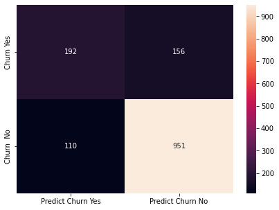

```python
result['TunedModel-Standardize-DataSet'] = fit_n_print(model, X_train_std, X_test_std, y_train, y_test)
```

### Print the result of each model

```python
printResult(result)
```

| Model | Training accuracy | Tesing accuracy | auc | precision | recall | accuracy_cv | precision_cv | recall_cv | f1_cv | Elapsed |
| --- | --- | --- | --- | --- | --- | --- | --- | --- | --- | --- |
| BaseModel-with-original-dataset | 0.830138 | 0.814053 | 0.73653 | 0.634375 | 0.583333 | 0.772453 | 0.589843 | 0.51808 | 0.551527 | 2.139867 |
| BaseModel-Normalize-DataSet | 0.830138 | 0.814053 | 0.73653 | 0.634375 | 0.583333 | 0.772808 | 0.590724 | 0.51808 | 0.551907 | 1.803187 |
| BaseModel-Standardize-DataSet | 0.830138 | 0.814053 | 0.73653 | 0.634375 | 0.583333 | 0.772808 | 0.590827 | 0.517423 | 0.551574 | 1.668421 |
| TuningModel-with-original-dataset | 0.805467 | 0.806246 | 0.704311 | 0.636364 | 0.502874 | 0.790557 | 0.642981 | 0.510848 | 0.568625 | 1.296503 |
| TunedModel-Normalize-DataSet | 0.808129 | 0.811214 | 0.724024 | 0.635762 | 0.551724 | 0.792155 | 0.64676 | 0.514135 | 0.572252 | 1.23773 |
| TunedModel-Standardize-DataSet | 0.808129 | 0.811214 | 0.724024 | 0.635762 | 0.551724 | 0.7918 | 0.645938 | 0.513478 | 0.571496 | 1.238592 |

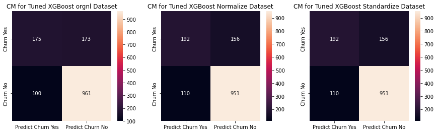

```python
compareConfusionMatrix('Tuned XGBoost', y_test, result['TuningModel-with-original-dataset'][10], result['TunedModel-Normalize-DataSet'][10], result['TunedModel-Standardize-DataSet'][10], labels=[1,0])
```

### DataSet is imbalance.

#### Testing accuracy of tuned and non tuned models are almost same. AUC score of "TuningModel-with-original-dataset " has been decreased . AUC score of Normalized dataset/ Standardize data set is almost same.

B. Improve performance of the XGBoost as much as possible. Also print best performing parameters along with train and test performance.

### Since dataset is imbalance. We need to find the weight and again perform the hypertuning.

```python
weight= churn_df.Churn.value_counts()[0]/churn_df.Churn.value_counts()[1]
weight
```

```
2.7683253076511503
```

### Finding best parameter with scale_post_weight parameter. It is used in imbalance dataset. Original Dataset is used for finding the best estimators

```python
final_model = report_randomiseSearchCV(xgb.XGBClassifier(random_state=42,scale_pos_weight =weight), params, X_train, y_train, X_test, y_test)
```

```
Fitting 3 folds for each of 200 candidates, totalling 600 fits
Model with rank: 1
Mean validation score: 0.846 (std: 0.008)
Parameters: {'colsample_bytree': 0.7270869310163225, 'gamma': 0.617651247794619, 'learning_rate': 0.07415601299434717, 'max_depth': 3, 'n_estimators': 179, 'subsample': 0.6163100566219055}

XGBClassifier(base_score=0.5, booster='gbtree', colsample_bylevel=1,
              colsample_bynode=1, colsample_bytree=0.7270869310163225,
              enable_categorical=False, gamma=0.617651247794619, gpu_id=-1,
              importance_type=None, interaction_constraints='',
              learning_rate=0.07415601299434717, max_delta_step=0, max_depth=3,
              min_child_weight=1, missing=nan, monotone_constraints='()',
              n_estimators=179, n_jobs=8, num_parallel_tree=1, predictor='auto',
              random_state=42, reg_alpha=0, reg_lambda=1,
              scale_pos_weight=2.7683253076511503, subsample=0.6163100566219055,
              tree_method='exact', validate_parameters=1, verbosity=None)
```

### Using best estimator, trying to find the best AUC score with Original Dataset

```python
result['TunedModel-With-ScalePosWeight-with-orignal_dataset']= fit_n_print(final_model, X_train, X_test, y_train, y_test)
```

### Hypertuning with Scale_pos_weight with normalized dataset

```python
final_model = report_randomiseSearchCV(xgb.XGBClassifier(random_state=42, scale_pos_weight =weight),params, X_train_norm, y_train, X_test_norm, y_test)
```

```
Fitting 3 folds for each of 200 candidates, totalling 600 fits
Model with rank: 1
Mean validation score: 0.846 (std: 0.008)
Parameters: {'colsample_bytree': 0.7270869310163225, 'gamma': 0.617651247794619, 'learning_rate': 0.07415601299434717, 'max_depth': 3, 'n_estimators': 179, 'subsample': 0.6163100566219055}

XGBClassifier(base_score=0.5, booster='gbtree', colsample_bylevel=1,
              colsample_bynode=1, colsample_bytree=0.7270869310163225,
              enable_categorical=False, gamma=0.617651247794619, gpu_id=-1,
              importance_type=None, interaction_constraints='',
              learning_rate=0.07415601299434717, max_delta_step=0, max_depth=3,
              min_child_weight=1, missing=nan, monotone_constraints='()',
              n_estimators=179, n_jobs=8, num_parallel_tree=1, predictor='auto',
              random_state=42, reg_alpha=0, reg_lambda=1,
              scale_pos_weight=2.7683253076511503, subsample=0.6163100566219055,
              tree_method='exact', validate_parameters=1, verbosity=None)
```

### Using best estimator, trying to find the best AUC score with Normalize Dataset

```python
result['TunedModel-With-ScalePosWeight-Normalize-DataSet']= fit_n_print(final_model, X_train_norm,X_test_norm, y_train, y_test)
```

### Hypertuning parameter with Scale_pos_weight

```python
final_model = report_randomiseSearchCV(xgb.XGBClassifier(random_state=42, scale_pos_weight =weight),params, X_train_std, y_train, X_test_std, y_test)
```

```
Fitting 3 folds for each of 200 candidates, totalling 600 fits
Model with rank: 1
Mean validation score: 0.846 (std: 0.009)
Parameters: {'colsample_bytree': 0.7270869310163225, 'gamma': 0.617651247794619, 'learning_rate': 0.07415601299434717, 'max_depth': 3, 'n_estimators': 179, 'subsample': 0.6163100566219055}

XGBClassifier(base_score=0.5, booster='gbtree', colsample_bylevel=1,
              colsample_bynode=1, colsample_bytree=0.7270869310163225,
              enable_categorical=False, gamma=0.617651247794619, gpu_id=-1,
              importance_type=None, interaction_constraints='',
              learning_rate=0.07415601299434717, max_delta_step=0, max_depth=3,
              min_child_weight=1, missing=nan, monotone_constraints='()',
              n_estimators=179, n_jobs=8, num_parallel_tree=1, predictor='auto',
              random_state=42, reg_alpha=0, reg_lambda=1,
              scale_pos_weight=2.7683253076511503, subsample=0.6163100566219055,
              tree_method='exact', validate_parameters=1, verbosity=None)
```

### Using best estimator, trying to find the best AUC score with Standardize Dataset

```python
result['TunedModel-With-ScalePosWeight-Standardize-DataSet']= fit_n_print(final_model, X_train_std,X_test_std, y_train, y_test)
```

### Print the result of all model with accuracy parameters

```python
printResult(result)
```

| Model | Training accuracy | Tesing accuracy | auc | precision | recall | accuracy_cv | precision_cv | recall_cv | f1_cv | Elapsed |
| --- | --- | --- | --- | --- | --- | --- | --- | --- | --- | --- |
| BaseModel-with-original-dataset | 0.830138 | 0.814053 | 0.73653 | 0.634375 | 0.583333 | 0.772453 | 0.589843 | 0.51808 | 0.551527 | 2.139867 |
| BaseModel-Normalize-DataSet | 0.830138 | 0.814053 | 0.73653 | 0.634375 | 0.583333 | 0.772808 | 0.590724 | 0.51808 | 0.551907 | 1.803187 |
| BaseModel-Standardize-DataSet | 0.830138 | 0.814053 | 0.73653 | 0.634375 | 0.583333 | 0.772808 | 0.590827 | 0.517423 | 0.551574 | 1.668421 |
| TuningModel-with-original-dataset | 0.805467 | 0.806246 | 0.704311 | 0.636364 | 0.502874 | 0.790557 | 0.642981 | 0.510848 | 0.568625 | 1.296503 |
| TunedModel-Normalize-DataSet | 0.808129 | 0.811214 | 0.724024 | 0.635762 | 0.551724 | 0.792155 | 0.64676 | 0.514135 | 0.572252 | 1.23773 |
| TunedModel-Standardize-DataSet | 0.808129 | 0.811214 | 0.724024 | 0.635762 | 0.551724 | 0.7918 | 0.645938 | 0.513478 | 0.571496 | 1.238592 |
| TunedModel-With-ScalePosWeight-with-orignal_dataset | 0.723997 | 0.722498 | 0.769395 | 0.466563 | 0.862069 | 0.747781 | 0.521917 | 0.789612 | 0.628396 | 1.129966 |
| TunedModel-With-ScalePosWeight-Normalize-DataSet | 0.723997 | 0.722498 | 0.769395 | 0.466563 | 0.862069 | 0.747781 | 0.521917 | 0.789612 | 0.628396 | 1.199693 |
| TunedModel-With-ScalePosWeight-Standardize-DataSet | 0.723997 | 0.722498 | 0.769395 | 0.466563 | 0.862069 | 0.748669 | 0.523116 | 0.789612 | 0.629247 | 1.176439 |

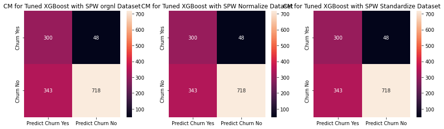

```python
compareConfusionMatrix('Tuned XGBoost with SPW', y_test, result['TunedModel-With-ScalePosWeight-with-orignal_dataset'][10], result['TunedModel-With-ScalePosWeight-Normalize-DataSet'][10], result['TunedModel-With-ScalePosWeight-Standardize-DataSet'][10], labels=[1,0])
```

### Using Scaleposweight parameter, AUC score is increased. AUC score is greater than 76% which is 3-4% bigger than tuned/Base model

### Tuned model with scale pos weight are having the same AUC score.

```python
import os
os.environ["PATH"] += os.pathsep + 'C:/Program Files (x86)/Graphviz/bin'
# converts the target tree to a graphviz instance
xgb.to_graphviz(final_model, num_trees=final_model.best_iteration)
```

[figure not shown]

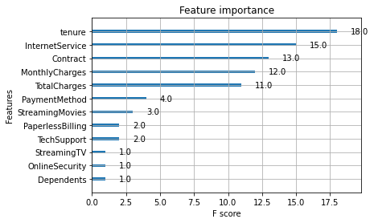

```python
xgb.plot_importance(final_model)
```

### Below is the most important feature of dataframe.

### tenure is highest important feature

### Internet service Contract, monthlyCharges, TotalCharges are som more important feature.

### Decision tree is described with is taking the imprtant feature to plot and predict

# PART B

DOMAIN: IT • CONTEXT: The purpose is to build a machine learning workflow that will work autonomously irrespective of Data and users can save efforts involved in building workflows for each dataset. • PROJECT OBJECTIVE: Build a machine learning workflow that will run autonomously with the csv file and return best performing model.

### 1 Build a simple ML workflow which will accept a single ‘.csv’ file as input and return a trained base model that can be used for predictions. You can use1 Dataset from Part 1 (single/merged).

### 2. Create separate functions for various purposes.

### To achieve the above functionality. We need to create multiple method and create one main method name workflow. Workflow method have many method inside it which is doing data exploration, data cleaning, visualization, model cleaning.

```python
def replaceMissingValueWithNull(df):
    """
    replaceMissingValueWithNull iterate each column and check for null value.
    It also check where user add two or more spaces. If yes, then it will replace that spaces with null value.

    :param p1: accept a dataframe
    :return: it return true or false. It true, then missing value is present.
    """
    isColumnContainMissingValue = False
    catagorical_col = df.select_dtypes(include=['object']).columns
    for column in  catagorical_col:
        if (len(df[df[column].astype(str).str.fullmatch(r"\s*")])):
            df[column] = np.where(df[column].astype(str).str.fullmatch(r"\s*"),np.nan,df[column])
            print('Missing value is found for column : ', column)
            isColumnContainMissingValue = True;
    return isColumnContainMissingValue, df;
```

```python
def findAndReplaceMissingValue(df):
    """
    findAndReplaceMissingValue does check for missing value. If the missing value is present, then return true.
    It also check where user add two or more spaces. If yes, then it will replace that spaces with null value.

    :param p1: accept a dataframe
    :return: it return Updated dataframe.
    """
    if df.isna().any().any():
        isMissingValueFound , df = replaceMissingValueWithNull(df)
        print('Missing value is found in dataframe')
    else:
        isMissingValueFound , df = replaceMissingValueWithNull(df);
        if not isMissingValueFound:
            print('No missing value found in dataset')
    return df
```

```python
def find_column_missing_value(df):
    """
    findAndReplaceMissingValue does check for missing value. If the missing value is present, then return true.
    It also check where user add two or more spaces. If yes, then it will replace that spaces with null value.

    :param p1: accept a dataframe
    :return: None.
    """
    print("Printing Column and Missing value")
    display(df.isna().sum())
```

```python
def find_missing_row_values(df):
    """
    Show the missing row

    :param p1: accept a dataframe
    :return: NONE.
    """
    print("Showing Total missing value's records")
    display(df[df.isnull().any(axis=1)])
```

```python
def printUniqueValues(df):
    """
    Show the unique value of each column

    :param p1: accept a dataframe
    :return: NONE.
    """
    print("Printing unique column of each column")
    for column in df.columns:
        print("{} ->  {} ".format(column,df[column].unique()))
```

```python
def imputeMissingValue(df, column, strategy):
    """
    Cover the missing value by mean/Mode/Median. It also validate the column and strategy

    :param p1: accept a dataframe
    :return: updated dataframe.
    """
    allowedStrategy = ['mean', 'median', 'mode']
    if column in df.columns:
        if strategy in allowedStrategy:
            if strategy == 'mean':
                df[column] = df[column].fillna(df[column].mean());
                print('Missing data is replaced with mean value')
            if strategy == 'median':
                df[column] = df[column].fillna(df[column].median());
                print('Missing data is replaced with median value')
            if strategy == 'mode':
                df[column] = df[column].fillna(df[column].mode());
                print('Missing data is replaced with Mode value')
        else:
            print('Strategy is not present in allowed strategy list.Please provide the correct value. The allowed strategy list is ' , allowedStrategy)
    else:
        print(column , ' is not present in dataframe. Please check')
    return df;
```

```python
def is_duplicate_rows_present(df):
    """
    Check for duplicate value

    :param p1: accept a dataframe
    :return: true/false. Return true if it finds duplicate.
    """
    df.duplicated().any()
```

```python
def find_and_drop_duplicateRecords(df):
    """
    Check for duplicate value and remove duplicates

    :param p1: accept a dataframe
    :return: return updated dataframe.
    """
    if is_duplicate_rows_present(df):
        df.drop_duplicates(inplace=True)
        print('Duplicate Records have been removed')
    else:
        print('No Duplicate Records present')
    return df;
```

```python
def removeNull(df):
    """
    Remove the null values

    :param p1: accept a dataframe
    :return: return updated dataframe.
    """
    print('removing null values from the dataframe')
    df.dropna(inplace=True)
    print("Successfully dropping null value from dataset");
    return df;
```

```python
def printRecord(df, n=10):
    """
    print the top N record. Default value of N is 10

    :param p1: accept a dataframe
    :return: dataframe 10 records.
    """
    display(df.head(n))
```

```python
def info(df):
    """
    print the info on dataframe

    :param p1: accept a dataframe
    :return: dataframe 10 records.
    """
    display(df.info())
```

```python
def describe(df):
    """
    print the describe on dataframe

    :param p1: accept a dataframe
    :return: describe outcome.
    """
    display(df.describe().T)
```

```python
def shape(df):
    """
    print the total numer of row/columns

    :param p1: accept a dataframe
    :return: NONE.
    """
    print('Total number of row ', df.shape[0])
    print('Total number of column ', df.shape[1])
```

```python
def convertDataType(df, column, dtype):
    """
    Convert the dataframe column dtype

    :param p1: accept a dataframe
    :param p1: accept a column
    :param p1: convert dtype
    :return: updated df.
    """
    allowed_dtypes = ['object','int64', 'float64', 'bool', 'datetime64', 'category']
    if dtype not in allowed_dtypes:
        print(dtype , ' is not present in allowed list. Please check it')
        raise Exception(dtype , ' is not present in allowed list. Please check it')
    if column not in df.columns:
        raise Exception(column , ' is not present in dataset. Please check it')
    df[column] = df[column].astype(dtype)
    print('dtype of ', column , ' has been changed to ', dtype)
    return df;
```

```python
def scaleDataSet(Scaler, X_train, y_train, numerical_columns):
    """
    It uses the scaler and data into the desired scaler

    param p1: accept a Scaler
    param p2: accept a X_train
    param p3: accept a  y_train
    Param p4: accept the numerical_columns
    :return: updated df.
    """
    X_train_scale = X_train.copy()
    X_test_scale = X_test.copy()
    scaler = Scaler.fit(X_train[numerical_columns])
    X_train_scale[numerical_columns] = scaler.transform(X_train_scale[numerical_columns])
    X_test_scale[numerical_columns] = scaler.transform(X_test_scale[numerical_columns])
    print('Successfully Scale the dataset using ', type(Scaler))
    return X_train_scale, X_test_scale
```

```python
def plt_hist(df, target, excluded_columns=[]):
    '''
    It will display the histogram . User has to provide the target column and excluded column.
    Param 1: dataframe
    Param 2: target column
    Param 3: Excluded column list
    '''
    if not excluded_columns:
        total_column = df.select_dtypes(include=['object']).columns
    else:
        total_column = df.drop(excluded_columns, axis=1).select_dtypes(include=['object']).columns
    N = len(total_column)
    cols =3;
    rows = int(math.ceil(N/cols))
    fig,axs = plt.subplots(nrows=rows, ncols=cols, figsize=(20,10))
    axs = axs.flatten()
    for ax in axs:
        ax.set_axis_off()
    for i, column in enumerate(total_column):
        if column != target or (not excluded_columns and column not in excluded_columns):
            sns.countplot( x=column, hue=target, data=df, ax=axs[i])
            axs[i].set_axis_on()
            axs[i].set_title(column+" hist plot")
    plt.show()
```

```python
def plotBox(df, x, y):
    N = len(y)
    cols =2;
    rows = int(math.ceil(N/cols))
    fig,axs = plt.subplots(nrows=rows, ncols=cols, figsize=(15,10))
    axs = axs.flatten()
    for i, ax in enumerate(axs):
        ax.set_axis_off()
    for i, column in enumerate(y):
        sns.boxplot(data=df, x=x, y=column,ax = axs[i]);
        title = (column+ "-" + x + " plot");
        axs[i].set_title(title)
        axs[i].set_axis_on()
    plt.show()
```

```python
def make_autopct(values):
    def my_autopct(pct):
        total = sum(values)
        val = int(round(pct*total/100.0))
        return '{p:.2f}%  ({v:d})'.format(p=pct,v=val)
    return my_autopct
```

```python
def plotpieChart(df):
    cat_df = df.select_dtypes(include=["object"])
    N = len(cat_df.columns)
    cols =2;
    rows = int(math.ceil(N/cols))
    fig,axs = plt.subplots(nrows=rows, ncols=cols, figsize=(15,10))
    axs = axs.flatten()
    print(N , cols, rows)
    for i, ax in enumerate(axs):
        ax.set_axis_off()
    for i, column in enumerate(cat_df.columns):
        data = cat_df.groupby(column).size()
        data.plot(kind='pie',textprops={'fontsize': 10},
                                           autopct=lambda p: '{:.2f}%({:.0f})'.format(p,(p/100)*data.sum()), shadow=True)
        ax[i].set_xlabel(column, size=22)
        ax[i].set_ylabel('')
        axs[i].set_axis_on()
        plt.tight_layout()
    plt.show()
```

```python
def printConfusionMetric(y_test, y_pre, labels):
    cm = metrics.confusion_matrix(y_test, y_pre, labels=labels)
    df_cm = pd.DataFrame(cm, index = [i for i in labels],
                  columns = ["Predict "+ str(i) for i in labels])
    plt.figure(figsize = (7,5));
    sns.heatmap(df_cm, annot=True, fmt='g');
```

```python
def data_exploration(file_name):
    print('----------------------------------Retrieving DataSet from File START---------------------------------------------')
    df = pd.read_csv(file_name)
    print('----------------------------------Retrieving DataSet from File END------------------------------------')
    print('')
    print('')
    print('----------------------------------Print the Dataframe START---------------------------------------------')
    printRecord(df,10)
    print('----------------------------------Print the Dataframe  END------------------------------------')
    print('')
    print('')
    print('----------------------------------PRINT INFO START---------------------------------------------')
    info(df)
    print('----------------------------------PRINT INFO  END------------------------------------')
    print('')
    print('')
    print('----------------------------------PRINT ROW/COLUMn START---------------------------------------------')
    shape(df)
    print('----------------------------------PRINT ROW/COLUMn END------------------------------------')
    print('')
    print('')
    return df
```

```python
def dropcolumn(df, column):
    '''
    This method remove the column from the datafram
    Param1 : Contain the dataframe
    Param2 : Contain the column nme which user want to remove
    '''
    if column in df.columns:
        df.drop(column, axis=1 ,inplace=True)
        print(column , ' has been dropped successfully')
    else:
        print(column, ' is not found in dataset. Please check the column name');
    return df
```

```python
def replaceColumnValue(df, column , fromvalue, to_value):
    '''
    This method replace the column value.
    Param 1 : accppt the dataframe object
    Param2 : Contain the column in which value to be replaced
    Param3 : From value which need to be replaced
    Param4: to value which is used to replace the value
    '''
    df[column]  = df[column].replace({fromvalue : to_value})
    print(fromvalue+ 'has been replaced successfully with '+ to_value+ ' in column '+ column)
    return df;
```

```python
def pre_processing(df):
    print('----------------------------------PRINT DESCRIBE START---------------------------------------------')
    describe(df)
    print('----------------------------------PRINT DESCRIBE END---------------------------------------------')
    print('')
    print('')
    print('----------------------------------Find AND REPLACE MISSING VALUE START---------------------------------------------')
    df = findAndReplaceMissingValue(df)
    print('----------------------------------Find AND REPLACE MISSING VALUE END------------------------------------')
    print('')
    print('')
    print('---------------------------------FIND MISSING ROW START-------------------------------------')
    find_missing_row_values(df)
    print('---------------------------------FIND MISSING ROW END---------------------------------------------------')
    print('')
    print('')
    print('---------------------------------PRINT COLUMN WISE MISSING VALUE START----------------------------------------')
    find_column_missing_value(df)
    print('---------------------------------PRINT COLUMN WISE MISSING VALUE END------------------------------------')
    print('')
    print('')
    print('--------------------------------REMOVE NULL RECORD START-------------------------------------')
    df = removeNull(df)
    print('--------------------------------REMOVE NULL RECORD END--------------------------------------------------')
    print('')
    print('')
    print('--------------------------------FIND AND DROP DUPLICATE ROWS START---------------------------------------------')
    df = find_and_drop_duplicateRecords(df)
    print('--------------------------------FIND AND DROP DUPLICATE ROWS END----------------------------------------------')
    print('')
    print('')
    print('---------------------------------Checking COlumn wise Missing value again Start----------------------------------------')
    find_column_missing_value(df)
    print('---------------------------------Checking COlumn wise Missing value again END------------------------------------')
    print('')
    print('')
    print('-------------------------------PRINT UNIQUE VALUES OF EACH COLUMN START-----------------------------------------')
    printUniqueValues(df)
    print('-------------------------------PRINT UNIQUE VALUES OF EACH COLUMN END-----------------------------------------')
    print('')
    print('')
    print('--------------------------------Impute Missing Values START---------------------------------------------')
    df = imputeMissingValue(df, 'TotalCharges', 'median')
    print('-------------------------------Impute Missing Values END-----------------------------------------')
    print('')
    print('')
    print('--------------------------------Convert DataTypes START---------------------------------------------')
    df = convertDataType(df, 'MonthlyCharges', 'float64')
    df = convertDataType(df, 'TotalCharges', 'float64')
    print('--------------------------------Convert DataTypes END---------------------------------------------')
    print('')
    print('')
    print('--------------------------------Remove Unneed columns START---------------------------------------------')
    df = dropcolumn(df, 'customerID')
    print('--------------------------------Remove Unneed columnsConvert DataTypes END---------------------------------------------')
    print('')
    print('')
    print('--------------------------------Replacing Columns Value START---------------------------------------------')
    replace_cols = [ 'OnlineSecurity', 'OnlineBackup', 'DeviceProtection','TechSupport','StreamingTV', 'StreamingMovies']
    for column in replace_cols :
        df = replaceColumnValue(df, column, 'No internet service', 'No')
    print('--------------------------------Replacing Columns Value END---------------------------------------------')
    print('')
    print('')
    return df
```

```python
def visualization(df):
    print('----------------------------------Visualization of histogram START---------------------------------------------')
    display(df)

    plt_hist(df, 'Churn')
    print('----------------------------------Visualization of histogram END---------------------------------------------')
    print('')
    print('')
    print('----------------------------------Visualization of BoxPlot START---------------------------------------------')
    plotBox(df, 'Churn', ['tenure','MonthlyCharges','TotalCharges'])
    print('----------------------------------Visualization of BoxPlot END---------------------------------------------')
    print('')
    print('')
#     print('----------------------------------Visualization of PiePlot START---------------------------------------------')
#     plotpieChart(df)
#     print('----------------------------------Visualization of PiePlot END---------------------------------------------')
    print('')
    print('')
```

```python
def oneHotEncoding(df, columns):
    '''This method do one hot encoding
    Param 1: dataframe
    Param2 : List of columns value in which one hot encoding to be used.
    '''
    print('Performing One hot encoding in columns ', columns)
    df = pd.get_dummies(df, columns=columns, drop_first=True)
    return df;
```

```python
def performing_label_encoding(df, columns):
    '''This method do label encoding
    Param 1: dataframe
    Param2 : List of columns value in which label encoding to be used.
    '''
    labelEncoder = LabelEncoder()
    for column  in columns:
        df[column]=labelEncoder.fit_transform(df[column])
    return df;
```

```python
X_train=X_test=y_train=y_test= None
def performTrainTestSplit(df, targetColumn, test_size=0.20):
    '''Split the dataset into train and test
    Param1 : Accept the dataframe
    Param2: target column name
    Param3: test size. By default it is 20%
    '''
    global X_train,X_test, y_train, y_test;
    X = churn_df.drop(targetColumn,axis=1)
    y = churn_df[[targetColumn]]
    X_train, X_test, y_train, y_test = train_test_split(X, y, test_size=test_size, random_state=1, stratify=y)
    print('Successfully spliting the test dataset into ', test_size)
    return X_train, X_test, y_train, y_test;
```

```python
X_train_norm= X_test_norm =None
X_train_std= X_test_std = None
def data_modeling(df):
    global X_train_norm, X_test_norm,X_train_std, X_test_std;
    print('----------------------------------One Hot Encoding START---------------------------------------------')
    df = oneHotEncoding(df, columns= ['gender', 'Partner', 'Dependents', 'PhoneService', 'MultipleLines', 'InternetService', 'OnlineSecurity', 'OnlineBackup', 'DeviceProtection', 'TechSupport', 'StreamingTV', 'StreamingMovies', 'PaperlessBilling', 'PaymentMethod'])
    print('----------------------------------One Hot Encoding End---------------------------------------------')
    print('')
    print('')
    print('----------------------------------Label Encoding START---------------------------------------------')
    df = performing_label_encoding(df, columns= ['Contract', 'Churn'])
    print('----------------------------------Label Encoding End---------------------------------------------')
    print('')
    print('')
    print('----------------------------------Split Train_test START---------------------------------------------')
    X_train, X_test, y_train, y_test = performTrainTestSplit(df, 'Churn', test_size=0.20)
    print('----------------------------------Split Train_test End---------------------------------------------')
    print('')
    print('')
    print('----------------------------------Normaization/Standardization START---------------------------------------------')
    columns = X_train.columns
    numerical_columns = ['tenure', 'MonthlyCharges', 'TotalCharges']
    X_train_norm, X_test_norm = scaleDataSet(MinMaxScaler(), X_train, y_train, numerical_columns)
    X_train_std, X_test_std = scaleDataSet(StandardScaler(), X_train, y_train, numerical_columns)

    print('----------------------------------Normaization/Standardization End---------------------------------------------')
    print('')
    print('')
    print('----------------------------------Prepare A XGBoost START---------------------------------------------')
    xgBoost = xgb.XGBClassifier(random_state=1)
    fit_n_print(model,X_train, X_test,y_train, y_test)
    print('----------------------------------Prepare A XGBoost END---------------------------------------------')
    return xgBoost;
```

```python
def workflow(file_name):

    print('----------------------------------Data Exploration START---------------------------------------------')
    df = data_exploration(file_name)
    print('----------------------------------Data Exploration END---------------------------------------------')
    print('----------------------------------Data Pre Processing START---------------------------------------------')
    df = pre_processing(df)
    print('----------------------------------Data Pre Processing END---------------------------------------------')
    print('----------------------------------Visualization START---------------------------------------------')
    visualization(df)
    print('----------------------------------Visualization END---------------------------------------------')
    print('----------------------------------Model START---------------------------------------------')
    model = data_modeling(df)
    print('----------------------------------Model END---------------------------------------------')
    return model
```

```
----------------------------------Data Exploration START---------------------------------------------
----------------------------------Retrieving DataSet from File START---------------------------------------------
----------------------------------Retrieving DataSet from File END------------------------------------


----------------------------------Print the Dataframe START---------------------------------------------
```

|  | customerID | gender | SeniorCitizen | Partner | Dependents | tenure | PhoneService | MultipleLines | InternetService | OnlineSecurity | ... | DeviceProtection | TechSupport | StreamingTV | StreamingMovies | Contract | PaperlessBilling | PaymentMethod | MonthlyCharges | TotalCharges | Churn |
| --- | --- | --- | --- | --- | --- | --- | --- | --- | --- | --- | --- | --- | --- | --- | --- | --- | --- | --- | --- | --- | --- |
| 0 | 7590-VHVEG | Female | 0 | Yes | No | 1 | No | No phone service | DSL | No | ... | No | No | No | No | Month-to-month | Yes | Electronic check | 29.85 | 29.85 | No |
| 1 | 5575-GNVDE | Male | 0 | No | No | 34 | Yes | No | DSL | Yes | ... | Yes | No | No | No | One year | No | Mailed check | 56.95 | 1889.5 | No |
| 2 | 3668-QPYBK | Male | 0 | No | No | 2 | Yes | No | DSL | Yes | ... | No | No | No | No | Month-to-month | Yes | Mailed check | 53.85 | 108.15 | Yes |
| 3 | 7795-CFOCW | Male | 0 | No | No | 45 | No | No phone service | DSL | Yes | ... | Yes | Yes | No | No | One year | No | Bank transfer (automatic) | 42.30 | 1840.75 | No |
| 4 | 9237-HQITU | Female | 0 | No | No | 2 | Yes | No | Fiber optic | No | ... | No | No | No | No | Month-to-month | Yes | Electronic check | 70.70 | 151.65 | Yes |
| 5 | 9305-CDSKC | Female | 0 | No | No | 8 | Yes | Yes | Fiber optic | No | ... | Yes | No | Yes | Yes | Month-to-month | Yes | Electronic check | 99.65 | 820.5 | Yes |
| 6 | 1452-KIOVK | Male | 0 | No | Yes | 22 | Yes | Yes | Fiber optic | No | ... | No | No | Yes | No | Month-to-month | Yes | Credit card (automatic) | 89.10 | 1949.4 | No |
| 7 | 6713-OKOMC | Female | 0 | No | No | 10 | No | No phone service | DSL | Yes | ... | No | No | No | No | Month-to-month | No | Mailed check | 29.75 | 301.9 | No |
| 8 | 7892-POOKP | Female | 0 | Yes | No | 28 | Yes | Yes | Fiber optic | No | ... | Yes | Yes | Yes | Yes | Month-to-month | Yes | Electronic check | 104.80 | 3046.05 | Yes |
| 9 | 6388-TABGU | Male | 0 | No | Yes | 62 | Yes | No | DSL | Yes | ... | No | No | No | No | One year | No | Bank transfer (automatic) | 56.15 | 3487.95 | No |

10 rows × 21 columns

```
----------------------------------Print the Dataframe  END------------------------------------


----------------------------------PRINT INFO START---------------------------------------------
<class 'pandas.core.frame.DataFrame'>
RangeIndex: 7043 entries, 0 to 7042
Data columns (total 21 columns):
 #   Column            Non-Null Count  Dtype
---  ------            --------------  -----
 0   customerID        7043 non-null   object
 1   gender            7043 non-null   object
 2   SeniorCitizen     7043 non-null   int64
 3   Partner           7043 non-null   object
 4   Dependents        7043 non-null   object
 5   tenure            7043 non-null   int64
 6   PhoneService      7043 non-null   object
 7   MultipleLines     7043 non-null   object
 8   InternetService   7043 non-null   object
 9   OnlineSecurity    7043 non-null   object
 10  OnlineBackup      7043 non-null   object
 11  DeviceProtection  7043 non-null   object
 12  TechSupport       7043 non-null   object
 13  StreamingTV       7043 non-null   object
 14  StreamingMovies   7043 non-null   object
 15  Contract          7043 non-null   object
 16  PaperlessBilling  7043 non-null   object
 17  PaymentMethod     7043 non-null   object
 18  MonthlyCharges    7043 non-null   float64
 19  TotalCharges      7043 non-null   object
 20  Churn             7043 non-null   object
dtypes: float64(1), int64(2), object(18)
memory usage: 1.1+ MB
```

```
None
```

```
----------------------------------PRINT INFO  END------------------------------------


----------------------------------PRINT ROW/COLUMn START---------------------------------------------
Total number of row  7043
Total number of column  21
----------------------------------PRINT ROW/COLUMn END------------------------------------


----------------------------------Data Exploration END---------------------------------------------
----------------------------------Data Pre Processing START---------------------------------------------
----------------------------------PRINT DESCRIBE START---------------------------------------------
```

|  | count | mean | std | min | 25% | 50% | 75% | max |
| --- | --- | --- | --- | --- | --- | --- | --- | --- |
| SeniorCitizen | 7043.0 | 0.162147 | 0.368612 | 0.00 | 0.0 | 0.00 | 0.00 | 1.00 |
| tenure | 7043.0 | 32.371149 | 24.559481 | 0.00 | 9.0 | 29.00 | 55.00 | 72.00 |
| MonthlyCharges | 7043.0 | 64.761692 | 30.090047 | 18.25 | 35.5 | 70.35 | 89.85 | 118.75 |

```
----------------------------------PRINT DESCRIBE END---------------------------------------------


----------------------------------Find AND REPLACE MISSING VALUE START---------------------------------------------
Missing value is found for column :  TotalCharges
----------------------------------Find AND REPLACE MISSING VALUE END------------------------------------


---------------------------------FIND MISSING ROW START-------------------------------------
Showing Total missing value's records
```

|  | customerID | gender | SeniorCitizen | Partner | Dependents | tenure | PhoneService | MultipleLines | InternetService | OnlineSecurity | ... | DeviceProtection | TechSupport | StreamingTV | StreamingMovies | Contract | PaperlessBilling | PaymentMethod | MonthlyCharges | TotalCharges | Churn |
| --- | --- | --- | --- | --- | --- | --- | --- | --- | --- | --- | --- | --- | --- | --- | --- | --- | --- | --- | --- | --- | --- |
| 488 | 4472-LVYGI | Female | 0 | Yes | Yes | 0 | No | No phone service | DSL | Yes | ... | Yes | Yes | Yes | No | Two year | Yes | Bank transfer (automatic) | 52.55 | NaN | No |
| 753 | 3115-CZMZD | Male | 0 | No | Yes | 0 | Yes | No | No | No internet service | ... | No internet service | No internet service | No internet service | No internet service | Two year | No | Mailed check | 20.25 | NaN | No |
| 936 | 5709-LVOEQ | Female | 0 | Yes | Yes | 0 | Yes | No | DSL | Yes | ... | Yes | No | Yes | Yes | Two year | No | Mailed check | 80.85 | NaN | No |
| 1082 | 4367-NUYAO | Male | 0 | Yes | Yes | 0 | Yes | Yes | No | No internet service | ... | No internet service | No internet service | No internet service | No internet service | Two year | No | Mailed check | 25.75 | NaN | No |
| 1340 | 1371-DWPAZ | Female | 0 | Yes | Yes | 0 | No | No phone service | DSL | Yes | ... | Yes | Yes | Yes | No | Two year | No | Credit card (automatic) | 56.05 | NaN | No |
| 3331 | 7644-OMVMY | Male | 0 | Yes | Yes | 0 | Yes | No | No | No internet service | ... | No internet service | No internet service | No internet service | No internet service | Two year | No | Mailed check | 19.85 | NaN | No |
| 3826 | 3213-VVOLG | Male | 0 | Yes | Yes | 0 | Yes | Yes | No | No internet service | ... | No internet service | No internet service | No internet service | No internet service | Two year | No | Mailed check | 25.35 | NaN | No |
| 4380 | 2520-SGTTA | Female | 0 | Yes | Yes | 0 | Yes | No | No | No internet service | ... | No internet service | No internet service | No internet service | No internet service | Two year | No | Mailed check | 20.00 | NaN | No |
| 5218 | 2923-ARZLG | Male | 0 | Yes | Yes | 0 | Yes | No | No | No internet service | ... | No internet service | No internet service | No internet service | No internet service | One year | Yes | Mailed check | 19.70 | NaN | No |
| 6670 | 4075-WKNIU | Female | 0 | Yes | Yes | 0 | Yes | Yes | DSL | No | ... | Yes | Yes | Yes | No | Two year | No | Mailed check | 73.35 | NaN | No |
| 6754 | 2775-SEFEE | Male | 0 | No | Yes | 0 | Yes | Yes | DSL | Yes | ... | No | Yes | No | No | Two year | Yes | Bank transfer (automatic) | 61.90 | NaN | No |

11 rows × 21 columns

```
---------------------------------FIND MISSING ROW END---------------------------------------------------


---------------------------------PRINT COLUMN WISE MISSING VALUE START----------------------------------------
Printing Column and Missing value
```

```
customerID           0
gender               0
SeniorCitizen        0
Partner              0
Dependents           0
tenure               0
PhoneService         0
MultipleLines        0
InternetService      0
OnlineSecurity       0
OnlineBackup         0
DeviceProtection     0
TechSupport          0
StreamingTV          0
StreamingMovies      0
Contract             0
PaperlessBilling     0
PaymentMethod        0
MonthlyCharges       0
TotalCharges        11
Churn                0
dtype: int64
```

```
---------------------------------PRINT COLUMN WISE MISSING VALUE END------------------------------------


--------------------------------REMOVE NULL RECORD START-------------------------------------
removing null values from the dataframe
Successfully dropping null value from dataset
--------------------------------REMOVE NULL RECORD END--------------------------------------------------


--------------------------------FIND AND DROP DUPLICATE ROWS START---------------------------------------------
No Duplicate Records present
--------------------------------FIND AND DROP DUPLICATE ROWS END----------------------------------------------


---------------------------------Checking COlumn wise Missing value again Start----------------------------------------
Printing Column and Missing value
```

```
customerID          0
gender              0
SeniorCitizen       0
Partner             0
Dependents          0
tenure              0
PhoneService        0
MultipleLines       0
InternetService     0
OnlineSecurity      0
OnlineBackup        0
DeviceProtection    0
TechSupport         0
StreamingTV         0
StreamingMovies     0
Contract            0
PaperlessBilling    0
PaymentMethod       0
MonthlyCharges      0
TotalCharges        0
Churn               0
dtype: int64
```

```
---------------------------------Checking COlumn wise Missing value again END------------------------------------


-------------------------------PRINT UNIQUE VALUES OF EACH COLUMN START-----------------------------------------
Printing unique column of each column
customerID ->  ['7590-VHVEG' '5575-GNVDE' '3668-QPYBK' ... '4801-JZAZL' '8361-LTMKD'
 '3186-AJIEK']
gender ->  ['Female' 'Male']
SeniorCitizen ->  [0 1]
Partner ->  ['Yes' 'No']
Dependents ->  ['No' 'Yes']
tenure ->  [ 1 34  2 45  8 22 10 28 62 13 16 58 49 25 69 52 71 21 12 30 47 72 17 27
  5 46 11 70 63 43 15 60 18 66  9  3 31 50 64 56  7 42 35 48 29 65 38 68
 32 55 37 36 41  6  4 33 67 23 57 61 14 20 53 40 59 24 44 19 54 51 26 39]
PhoneService ->  ['No' 'Yes']
MultipleLines ->  ['No phone service' 'No' 'Yes']
InternetService ->  ['DSL' 'Fiber optic' 'No']
OnlineSecurity ->  ['No' 'Yes' 'No internet service']
OnlineBackup ->  ['Yes' 'No' 'No internet service']
DeviceProtection ->  ['No' 'Yes' 'No internet service']
TechSupport ->  ['No' 'Yes' 'No internet service']
StreamingTV ->  ['No' 'Yes' 'No internet service']
StreamingMovies ->  ['No' 'Yes' 'No internet service']
Contract ->  ['Month-to-month' 'One year' 'Two year']
PaperlessBilling ->  ['Yes' 'No']
PaymentMethod ->  ['Electronic check' 'Mailed check' 'Bank transfer (automatic)'
 'Credit card (automatic)']
MonthlyCharges ->  [29.85 56.95 53.85 ... 63.1  44.2  78.7 ]
TotalCharges ->  ['29.85' '1889.5' '108.15' ... '346.45' '306.6' '6844.5']
Churn ->  ['No' 'Yes']
-------------------------------PRINT UNIQUE VALUES OF EACH COLUMN END-----------------------------------------


--------------------------------Impute Missing Values START---------------------------------------------
Missing data is replaced with median value
-------------------------------Impute Missing Values END-----------------------------------------


--------------------------------Convert DataTypes START---------------------------------------------
dtype of  MonthlyCharges  has been changed to  float64
dtype of  TotalCharges  has been changed to  float64
--------------------------------Convert DataTypes END---------------------------------------------


--------------------------------Remove Unneed columns START---------------------------------------------
customerID  has been dropped successfully
--------------------------------Remove Unneed columnsConvert DataTypes END---------------------------------------------


--------------------------------Replacing Columns Value START---------------------------------------------
No internet servicehas been replaced successfully with No in column OnlineSecurity
No internet servicehas been replaced successfully with No in column OnlineBackup
No internet servicehas been replaced successfully with No in column DeviceProtection
No internet servicehas been replaced successfully with No in column TechSupport
No internet servicehas been replaced successfully with No in column StreamingTV
No internet servicehas been replaced successfully with No in column StreamingMovies
--------------------------------Replacing Columns Value END---------------------------------------------


----------------------------------Data Pre Processing END---------------------------------------------
----------------------------------Visualization START---------------------------------------------
----------------------------------Visualization of histogram START---------------------------------------------
```

|  | gender | SeniorCitizen | Partner | Dependents | tenure | PhoneService | MultipleLines | InternetService | OnlineSecurity | OnlineBackup | DeviceProtection | TechSupport | StreamingTV | StreamingMovies | Contract | PaperlessBilling | PaymentMethod | MonthlyCharges | TotalCharges | Churn |
| --- | --- | --- | --- | --- | --- | --- | --- | --- | --- | --- | --- | --- | --- | --- | --- | --- | --- | --- | --- | --- |
| 0 | Female | 0 | Yes | No | 1 | No | No phone service | DSL | No | Yes | No | No | No | No | Month-to-month | Yes | Electronic check | 29.85 | 29.85 | No |
| 1 | Male | 0 | No | No | 34 | Yes | No | DSL | Yes | No | Yes | No | No | No | One year | No | Mailed check | 56.95 | 1889.50 | No |
| 2 | Male | 0 | No | No | 2 | Yes | No | DSL | Yes | Yes | No | No | No | No | Month-to-month | Yes | Mailed check | 53.85 | 108.15 | Yes |
| 3 | Male | 0 | No | No | 45 | No | No phone service | DSL | Yes | No | Yes | Yes | No | No | One year | No | Bank transfer (automatic) | 42.30 | 1840.75 | No |
| 4 | Female | 0 | No | No | 2 | Yes | No | Fiber optic | No | No | No | No | No | No | Month-to-month | Yes | Electronic check | 70.70 | 151.65 | Yes |
| ... | ... | ... | ... | ... | ... | ... | ... | ... | ... | ... | ... | ... | ... | ... | ... | ... | ... | ... | ... | ... |
| 7038 | Male | 0 | Yes | Yes | 24 | Yes | Yes | DSL | Yes | No | Yes | Yes | Yes | Yes | One year | Yes | Mailed check | 84.80 | 1990.50 | No |
| 7039 | Female | 0 | Yes | Yes | 72 | Yes | Yes | Fiber optic | No | Yes | Yes | No | Yes | Yes | One year | Yes | Credit card (automatic) | 103.20 | 7362.90 | No |
| 7040 | Female | 0 | Yes | Yes | 11 | No | No phone service | DSL | Yes | No | No | No | No | No | Month-to-month | Yes | Electronic check | 29.60 | 346.45 | No |
| 7041 | Male | 1 | Yes | No | 4 | Yes | Yes | Fiber optic | No | No | No | No | No | No | Month-to-month | Yes | Mailed check | 74.40 | 306.60 | Yes |
| 7042 | Male | 0 | No | No | 66 | Yes | No | Fiber optic | Yes | No | Yes | Yes | Yes | Yes | Two year | Yes | Bank transfer (automatic) | 105.65 | 6844.50 | No |

7032 rows × 20 columns

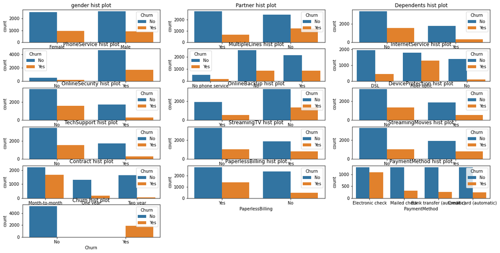

```
----------------------------------Visualization of histogram END---------------------------------------------


----------------------------------Visualization of BoxPlot START---------------------------------------------
```

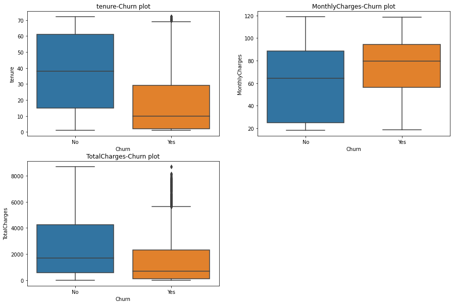

```
----------------------------------Visualization of BoxPlot END---------------------------------------------




----------------------------------Visualization END---------------------------------------------
----------------------------------Model START---------------------------------------------
----------------------------------One Hot Encoding START---------------------------------------------
Performing One hot encoding in columns  ['gender', 'Partner', 'Dependents', 'PhoneService', 'MultipleLines', 'InternetService', 'OnlineSecurity', 'OnlineBackup', 'DeviceProtection', 'TechSupport', 'StreamingTV', 'StreamingMovies', 'PaperlessBilling', 'PaymentMethod']
----------------------------------One Hot Encoding End---------------------------------------------


----------------------------------Label Encoding START---------------------------------------------
----------------------------------Label Encoding End---------------------------------------------


----------------------------------Split Train_test START---------------------------------------------
Successfully spliting the test dataset into  0.2
----------------------------------Split Train_test End---------------------------------------------


----------------------------------Normaization/Standardization START---------------------------------------------
Successfully Scale the dataset using  <class 'sklearn.preprocessing._data.MinMaxScaler'>
Successfully Scale the dataset using  <class 'sklearn.preprocessing._data.StandardScaler'>
----------------------------------Normaization/Standardization End---------------------------------------------


----------------------------------Prepare A XGBoost START---------------------------------------------
----------------------------------Prepare A XGBoost END---------------------------------------------
----------------------------------Model END---------------------------------------------
```

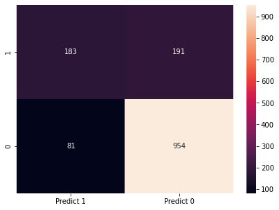

```python
model = workflow('merged.csv')
```